# Stroke Clinical Predictive Model

Tosin Dairo

MARCH 27, 2020

For easy reproducibility run CPM.rmd

## Clinical Predictive Model classifier for stroke

Stroke-CPM is a tool that takes information available about a patient and their observed predictive factors, and makes a prediction regarding their diagnosis and causal factors.

- Diagnosis – detects presence of stroke currently
- Causal Factors – assess whether observed predictive factor(s) is/are likely to be contributors to the development of stroke presently or in the future

#### Observed Factors:

- Gender
- Age
- Hypertension
- Heart Disease
- Ever Married
- Work Type
- Residence Type
- Average Glucose Level
- BMI
- Smoking Status

```r
{{knitr::spin_child('init.R')}}
```

Click init.R script to locate Rstudio environment setup and R package installation

#### Missing Values

```r
d$smoking_status <- na_if(d$smoking_status, "")
```

```python
print(r.d.isnull().sum())
```

```
## id                       0
## gender                   0
## age                      0
## hypertension             0
## heart_disease            0
## ever_married             0
## work_type                0
## Residence_type           0
## avg_glucose_level        0
## bmi                   1462
## smoking_status       13292
## stroke                   0
## dtype: int64
```

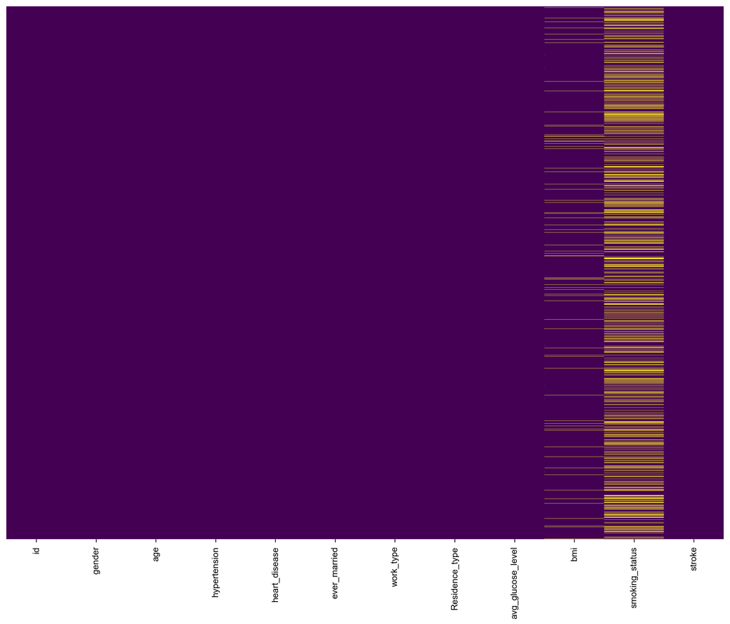

```python
fig, ax = plt.subplots(figsize=(14,12))
sns.heatmap(r.d.isnull(),yticklabels=False,cbar=False,cmap='viridis')
```

```r
d$gender <- as.factor(d$gender)
d$ever_married <- as.factor(d$ever_married)
d$work_type <- as.factor(d$work_type)
d$Residence_type <- as.factor(d$Residence_type)
d$smoking_status <- as.factor(d$smoking_status)
str(d)
```

```
## 'data.frame':    43400 obs. of  12 variables:
##  $ id               : int  30669 30468 16523 56543 46136 32257 52800 41413 15266 28674 ...
##  $ gender           : Factor w/ 3 levels "Female","Male",..: 2 2 1 1 2 1 1 1 1 1 ...
##  $ age              : num  3 58 8 70 14 47 52 75 32 74 ...
##  $ hypertension     : int  0 1 0 0 0 0 0 0 0 1 ...
##  $ heart_disease    : int  0 0 0 0 0 0 0 1 0 0 ...
##  $ ever_married     : Factor w/ 2 levels "No","Yes": 1 2 1 2 1 2 2 2 2 2 ...
##  $ work_type        : Factor w/ 5 levels "children","Govt_job",..: 1 4 4 4 3 4 4 5 4 5 ...
##  $ Residence_type   : Factor w/ 2 levels "Rural","Urban": 1 2 2 1 1 2 2 1 1 2 ...
##  $ avg_glucose_level: num  95.1 88 110.9 69 161.3 ...
##  $ bmi              : num  18 39.2 17.6 35.9 19.1 50.1 17.7 27 32.3 54.6 ...
##  $ smoking_status   : Factor w/ 4 levels "","formerly smoked",..: NA 3 NA 2 NA NA 2 3 4 3 ...
##  $ stroke           : int  0 0 0 0 0 0 0 0 0 0 ...
```

After checking for missing values, smoking status and bmi had missing values which could lead drawing an inaccurate inference about the stroke classification

#### Multiple Imputation for Missing Data

> To prevent bias in prediction, missing values are predicted and imputed into the stroke dataset

Using MICE package, Predictive Mean Matching and Poly Regreession technique are used to imput data missing at random from smoking status and bmi

```r
imp <- mice(d, seed = 3333)
imp$method
```

```
##                id            gender               age      hypertension
##                ""                ""                ""                ""
##     heart_disease      ever_married         work_type    Residence_type
##                ""                ""                ""                ""
## avg_glucose_level               bmi    smoking_status            stroke
##                ""             "pmm"         "polyreg"                ""
```

```r
dx <- mice::complete(imp)
```

#### Exploratory Analysis

Stroke class from exploratory pairplot below shows imbalance in stroke outcome, hypertension predictor and heart. Fitting a model on this imbalanced dataset would lead to overfitting whereby the trained model crams the train set data and predict wrongly on external datasets

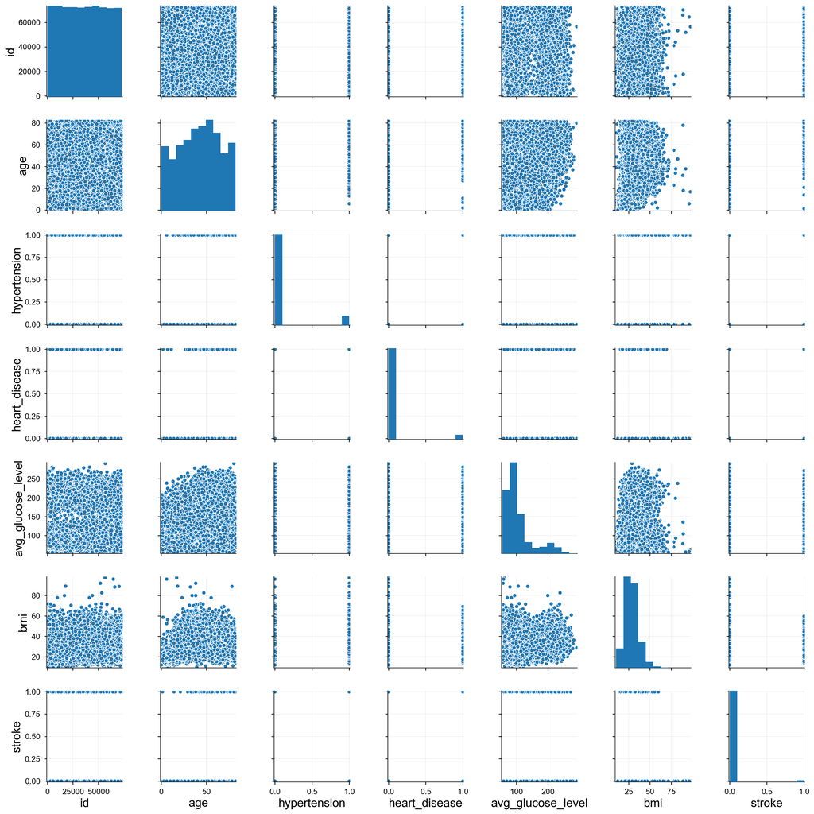

```python
fig, ax = plt.subplots(figsize=(14,12))
sns.pairplot(r.dx)
plt.show()
```

```r
{{knitr::spin_child('label_encode.R')}}
```

Click label_encode.R script to locate label encoder code

In order for us to predict the minority class in the imbalanced variable, the factor variables need to be encoded to vector types to enable prediction through oversampleing of minority class.

```r
result <- encode.fit_transform(dx)

dx_ <- result[[2]]
# encode.transform()
```

> Checking proportion of imbalance in the below variables

```r
tab_df(table(dx_$stroke), title = "Stroke Class")
```

Stroke Class

| 0 | 1 |
| --- | --- |
| 42617 | 783 |

```r
tab_df(table(dx_$hypertension), title = "Hypertension Class")
```

Hypertension Class

| 0 | 1 |
| --- | --- |
| 39339 | 4061 |

```r
tab_df(table(dx_$heart_disease), title = "Heart Disease Class")
```

Heart Disease Class

| 0 | 1 |
| --- | --- |
| 41338 | 2062 |

```r
dx_$hypertension <- as.factor(dx_$hypertension)
dx_$heart_disease <- as.factor(dx_$heart_disease)
dx_$stroke <- as.factor(dx_$stroke)
dx_$gender <- as.factor(dx_$gender)
dx_$ever_married <- as.factor(dx_$ever_married)
dx_$work_type <- as.factor(dx_$work_type)
dx_$Residence_type <- as.factor(dx_$Residence_type)
dx_$smoking_status <- as.factor(dx_$smoking_status)
str(dx_)
```

[output not shown]

#### Class Imbalance

```r
## Smote : Synthetic Minority Oversampling Technique To Handle Class Imbalancy In Binary Classification
set.seed(3333)

balanced_dx_ <-SMOTE(stroke ~., dx_, perc.over = 2100 , k = 5, perc.under = 160)

tab_df(table(balanced_dx_$stroke), title = "Stroke Class")
```

Stroke Class

| 0 | 1 |
| --- | --- |
| 26308 | 17226 |

#### Cross Validation:

For good predictions of stroke, a model must be well calibrated and have high discrimination. The input data was divided into two groups, in order to fit the data in one group and validate it in the other.This helps to reducing training bias.

```r
# Random sample indexes
train_index <- sample(1:nrow(balanced_dx_), 0.8 * nrow(balanced_dx_))
test_index <- setdiff(1:nrow(balanced_dx_), train_index)

# Build X_train, X_test
X_train <- balanced_dx_[train_index, 2:12]

X_test <- balanced_dx_[test_index, 2:12]
```

#### Model Training - Logistic Regression

To classify patients who have stroke or do not have stroke and to check for contributing causal factors to stroke, a binary classifier is built to predict the cases of stroke. State-of-the-art binary classifier Logistic Regression is applied. As per the [TRIPOD](https://www.tripod-statement.org/Portals/0/Tripod%20Checklist%20Prediction%20Model%20Development%20and%20Validation%20PDF.pdf) guidelines, we would need to report this stroke clinical predictive model in sufficient detail to allow for reproducability on a totally dufferent dataset.

```r
set.seed(3333)
model <- glm (stroke ~ ., data=X_train, family = binomial)
summary(model)
```

[output not shown]

###### Selection of contributing causal factors to stroke

```r
stepAIC(model, direction='both')
```

[output not shown]

```r
model_select <- glm(formula = stroke ~ gender + age + hypertension + heart_disease +
    ever_married + work_type + avg_glucose_level + smoking_status,
    family = binomial, data = X_train)
summary(model_select)
```

```
##
## Call:
## glm(formula = stroke ~ gender + age + hypertension + heart_disease +
##     ever_married + work_type + avg_glucose_level + smoking_status,
##     family = binomial, data = X_train)
##
## Deviance Residuals:
##     Min       1Q   Median       3Q      Max
## -3.3419  -0.4227  -0.1431   0.4958   3.3866
##
## Coefficients:
##                     Estimate Std. Error z value Pr(>|z|)
## (Intercept)       -5.960e+00  1.961e-01 -30.400  < 2e-16 ***
## gender2           -2.268e-01  3.338e-02  -6.794 1.09e-11 ***
## gender3           -1.277e+01  4.381e+02  -0.029    0.977
## age                9.584e-02  1.395e-03  68.683  < 2e-16 ***
## hypertension1      1.363e+00  3.759e-02  36.253  < 2e-16 ***
## heart_disease1     1.826e+00  4.370e-02  41.785  < 2e-16 ***
## ever_married2     -1.546e+00  4.509e-02 -34.293  < 2e-16 ***
## work_type2        -4.424e-01  2.051e-01  -2.157    0.031 *
## work_type3        -1.114e+01  8.998e+01  -0.124    0.901
## work_type4        -1.089e-01  2.079e-01  -0.524    0.600
## work_type5        -7.825e-02  2.076e-01  -0.377    0.706
## avg_glucose_level  4.674e-03  3.211e-04  14.557  < 2e-16 ***
## smoking_status2    2.021e-01  3.817e-02   5.294 1.20e-07 ***
## smoking_status3    4.055e-01  4.341e-02   9.341  < 2e-16 ***
## ---
## Signif. codes:  0 '***' 0.001 '**' 0.01 '*' 0.05 '.' 0.1 ' ' 1
##
## (Dispersion parameter for binomial family taken to be 1)
##
##     Null deviance: 46792  on 34826  degrees of freedom
## Residual deviance: 23305  on 34813  degrees of freedom
## AIC: 23333
##
## Number of Fisher Scoring iterations: 13
```

Using the stepwise AIC technique, the trained model for stroke has dropped the variables BMI and Reesident Type as they are not contributing factors that would lead to stroke. Stroke classification is non-preedicttive from the above 2 variables, and they have non-significant p-values which are > 0.05.

```r
## Predict the Values
predict <- predict(model, X_test, type = 'response')

## Create Confusion Matrix
table(X_test$stroke, predict > 0.5)
```

```
##
##     FALSE TRUE
##   0  4678  630
##   1   617 2782
```

#### Discrimination of Logistic Regression Classifier

Using the Discrimination, we check if trained CPM has a simultaneously high sensitivity and specificity. A receiver operator characteristic (ROC) curve is ploted using sensitivity against ‘1-specificity’ across the full range of potential cutpoints at 93%.

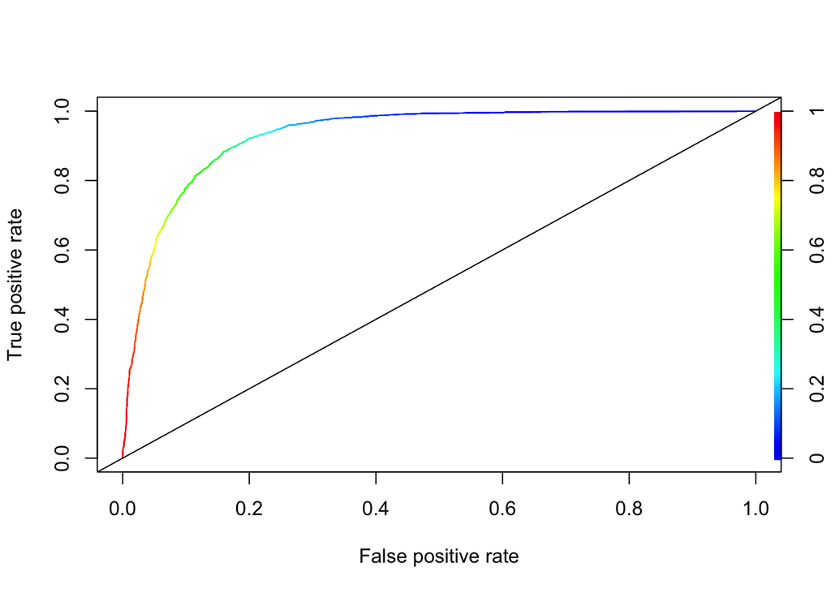

```r
#ROCR Curve
ROCRpred <- prediction(predict, X_test$stroke)
ROCRperf <- performance(ROCRpred, 'tpr','fpr')
p <- plot(ROCRperf, colorize = TRUE, text.adj = c(-0.2,1.7))
abline(a=0, b=1)
```

The ROC curve shows further to the top left of the graph, this indicates a great test.

```r
auc(roc(X_test$stroke ~ predict))
```

```
## Area under the curve: 0.9307
```

```r
hoslem.test(x = X_test$stroke, y=predict, g=10)
```

```
##
##  Hosmer and Lemeshow goodness of fit (GOF) test
##
## data:  X_test$stroke, predict
## X-squared = 8707, df = 8, p-value < 2.2e-16
```

To determine how far to the top left of the graph the curve is, the Area Under the Curve (AUC) is calculated

#### Model Training - Random Forest

To further check for a better prediction classifier, a Random Forest model is built check for contributing causal factors to stroke and also to classify patients who have stroke or do not have stroke. As per the [TRIPOD](https://www.tripod-statement.org/Portals/0/Tripod%20Checklist%20Prediction%20Model%20Development%20and%20Validation%20PDF.pdf) guidelines, we would need to report this stroke clinical predictive model in sufficient detail to allow for reproducability on a totally dufferent dataset.

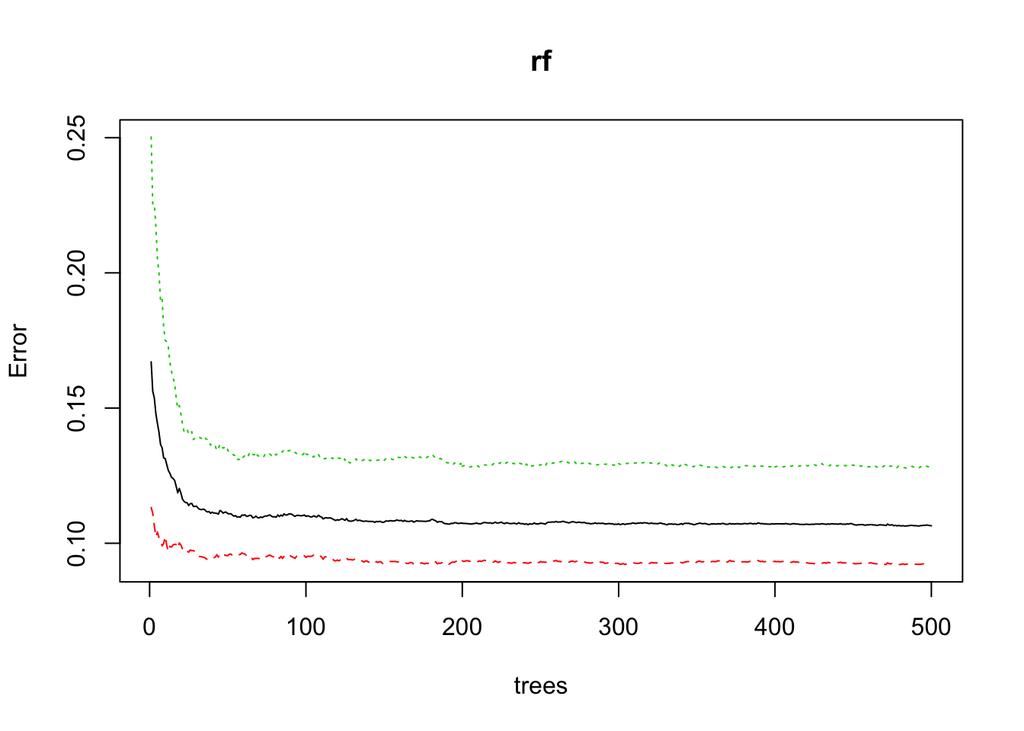

```r
set.seed(3333)
rf = randomForest(stroke ~ .,
                  ntree = 500,
                   data = X_train)
rf
plot(rf)
```

###### Selection of contributing causal factors to stroke

```r
varImp(rf)
```

[output not shown]

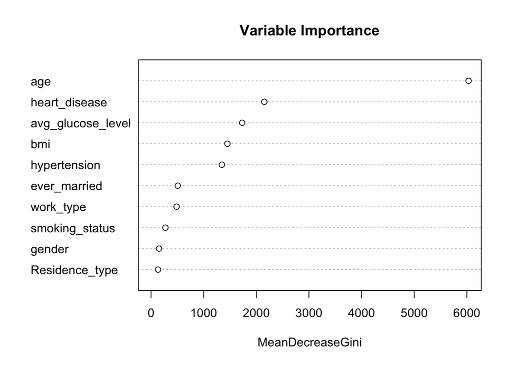

```r
## Important variables according to the model
varImpPlot(rf,
           sort = T,
           n.var=10,
           main="Variable Importance")
```

> After applying Random Forest classifier algorithm, all contributing causal factors were kept by the model and rated in order of importance as seen in the above plot

```r
predicted.response <- predict(rf, X_test)


confusionMatrix(data=predicted.response,
                reference=X_test$stroke)
```

```
## Confusion Matrix and Statistics
##
##           Reference
## Prediction    0    1
##          0 4844  447
##          1  464 2952
##
##                Accuracy : 0.8954
##                  95% CI : (0.8888, 0.9017)
##     No Information Rate : 0.6096
##     P-Value [Acc > NIR] : <2e-16
##
##                   Kappa : 0.7804
##
##  Mcnemar's Test P-Value : 0.596
##
##             Sensitivity : 0.9126
##             Specificity : 0.8685
##          Pos Pred Value : 0.9155
##          Neg Pred Value : 0.8642
##              Prevalence : 0.6096
##          Detection Rate : 0.5563
##    Detection Prevalence : 0.6077
##       Balanced Accuracy : 0.8905
##
##        'Positive' Class : 0
##
```

#### Discrimination of Random Forest Classifier

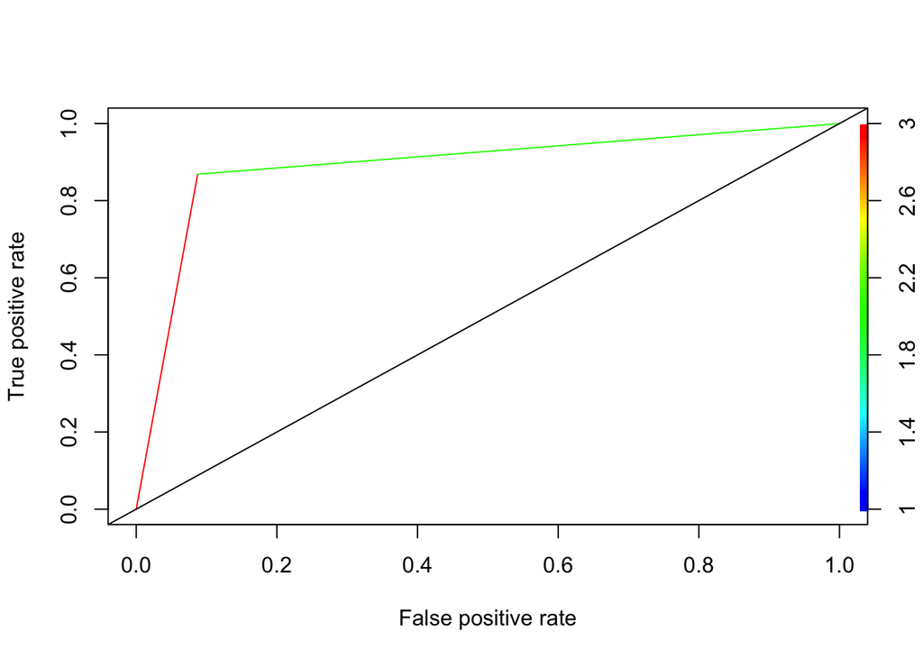

```r
#ROCR Curve
ROCRpred_rf <- prediction(as.numeric(predicted.response), X_test$stroke)
ROCRperf_rf <- performance(ROCRpred_rf, 'tpr','fpr')
plot(ROCRperf_rf, colorize = TRUE, text.adj = c(-0.2,1.7))
abline(a=0, b=1)
```

The ROC curve shows further to the top left of the graph, this indicates a great test, but is slightly lower than the Logistic Regression Classifier.

```r
auc(roc(X_test$stroke ~ as.numeric(predicted.response)))
```

```
## Area under the curve: 0.8905
```

```r
hoslem.test(x = X_test$stroke, y=as.numeric(predicted.response), g=10)
```

```
##
##  Hosmer and Lemeshow goodness of fit (GOF) test
##
## data:  X_test$stroke, as.numeric(predicted.response)
## X-squared = 8707, df = 8, p-value < 2.2e-16
```

To determine how far to the top left of the graph the curve is, the Area Under the Curve (AUC) is calculated

So the AUC for the Random Forest classifier is 0.89 which represents a near perfect discrimination

#### Conclusion

Overall logistic regression was selected as the best model to predict if a patient can have stroke or not. To achieve this and reduce the potential of bias and oveerfitting of trained model, imbalanced data are sampled because it is a common hurdle in healthcare. Also performed multiple imputation to predict missing data of smoke status in other ways as well